# Statistical inference

Ruth Gómez

October 21, 2017

## Random probability distribution

10.Calculate the binomial probability (n=4,m=12,p=0.2), where m=number of repetitions, n and (m-n) are the number of favorable (i.e., a) and unfavorable results (b) and p the probability of favorable results.

```r
dbinom(4, 12, 0.2)
```

```
## [1] 0.1328756
```

11.Simulate a binomial sample m=200 y and p=0.6.

```r
# Sample of 1
rbinom(1, 200, 0.6)
```

```
## [1] 115
```

```r
# Sample of 100
rbinom(100, 200, 0.6)
```

```
##   [1] 118 125 124 119 122 119 121 131 121 131 125 119 126 117 128 114 118
##  [18] 126 107 127 120 119 120 117 122 122 110 132 114 129 107 121 108 120
##  [35] 125 119 118 100 124 101 120 105 128 118 120 125 119 117 125 116 127
##  [52] 124 114 113 112 115 121 132 112 125 113 119 111 114 129 132 114 124
##  [69] 127 118 123 120 102 113 113 125 109 130 108 116 119 118 108 101 123
##  [86] 113 128 120 111 126 117 127 123 120 122 118 117 113 130 105
```

12.Coliform bacteria are randomly distributed in the Ebro river at an average concentration of 1 per 20cc of water. If we draw from the river a test tube containing 10cc of water, what is the chance that the sample contains exactly 2 coliform bacteria?

```r
dpois(2, 0.5)
```

```
## [1] 0.07581633
```

13.Calculate the cumulative probability of a Poisson distribution (k≤3,λ=3).

```r
ppois(3, 3)
```

```
## [1] 0.6472319
```

14.Calculate the cumulative probability of a Poisson distribution(k>1,λ=2).

```r
ppois(1, 2, lower=F)
```

```
## [1] 0.5939942
```

15.Simulate a sample m=200 of a Poisson distribution with λ = 4.3

```r
rpois(200, 4.3)
```

```
##   [1]  5  3  3  2  3  4  4  2  6  6  4  8  3  2  4  1  3  6  3  3  3  1  5
##  [24]  2  5  6  8  3  6  3  3  4  8  7  4  5  5  5  5  7  2  8  4  3  4  7
##  [47]  8  4  3  3  5  2  5  3  0  9  7  1  1  5  5  5  5  8  1  3  4  9  2
##  [70]  6  7  5  1  3  4  2  5  7  1  3  4  4  6  8  4  3  4  3  9  8  6  5
##  [93]  1  4  6  4  2  4  9  5  1  4  3  2  5  4  4  3  3  5  3  4  3  5  5
## [116]  4  4  1  3  3  2  4  7  5  2  3  1  6  4  2  4  2  5  5  3  5  4  7
## [139]  3  4  3  2  2  6  7  6  5  4  5  1  6  3  4  8  4  9  5  2  3  6  4
## [162]  7  8  3  4  5  7  2  2  4  4  8  1  2  3  1  3  4  4  2  3  3  1  5
## [185]  3  2  3  4  4  3  1  2  3  5  5  6  3  5 11  5
```

16.The number of crossovers per meiosis and chromosome (or chromosome region) is usually approximated to a Poisson distribution of probability. Relate the meiotic crossover with the following symbols of the Poisson distribution: k = *number of crossovers in a mesiosis and chromosome* λ = *mean of crossovers per meiosis and cromosome* What does f(4;5) mean? *The probability of 4 crossovers in a chromosome and meiosis when the mean are 5 crossovers.* Is there some sites more likely than others to be involved in a crossover? *Yes* If the function of probability of a chromosome is f (k, 6), which the probability function of a region whose size is a third of the chromosome? *f(k, 2)*

17.If the number of new mutations for each replication of a genome is 6, which is the probability of a replicated genome has 0 mutations.

```r
dpois(0, 6)
```

```
## [1] 0.002478752
```

18.If the number of crossover per meiosis in a chromosome is 4, calculate the probability of more than two crossover at a given meiosis for the chromosome.

```r
ppois(2, 4, lower=F)
```

```
## [1] 0.7618967
```

19.In a human population with zero population growth the government proposes aiding large families.If the budget allows only help 5.5% of families, how many children must have the families to receive the aid?

```r
qpois(1-0.055, 2)
```

```
## [1] 4
```

*5 children or more* 20.It is known that the probability of a nucleotide incorrectly assigned in a read of a sequencing technology X is 0.001. If a million reads are made, what is the probability that the number of erroneous reads is greater than 1500?

```r
# A million reads, multiplied by the probability of wrong reads = mean number of wrong reads
lambda<-1000000*0.001
ppois(1500, lambda, lower =F )
```

```
## [1] 2.097225e-49
```

21.Obtain the z value leaving an upper area = 7%.

```r
qpois(0.93,0.001)
```

```
## [1] 0
```

22.Calculate p (-155 ≤ x ≤ 185) for a distribution N(174.3,7.6).

```r
pnorm(185, 174.3, 7.6)-pnorm(-155, 174.3, 7.6)
```

```
## [1] 0.9204189
```

23.Calculate p (-0.9 ≤z≤0.9).

```r
pnorm(0.9)-pnorm(-0.9)
```

```
## [1] 0.6318797
```

24.Calculate the area (-2.43 ≤ x ≤1.81)

```r
pnorm(-2.43)-pnorm(1.81)
```

```
## [1] -0.9573027
```

25.Find the L value that fulfill p (-L ≤z≤ L) = 0.95.

```r
# The tails have to be (1-0.95)/2= 0.025
Llower <- qnorm(0.025)
Llower
```

```
## [1] -1.959964
```

```r
# Demonstration
pnorm(-Llower)-pnorm(Llower)
```

```
## [1] 0.95
```

26.Get by simulation a sample n=100 from distribution N(0,1).

```r
rnorm(100)
```

```
##   [1] -1.672503695 -0.393168624  0.851245786  0.569860098 -1.372504692
##   [6] -1.171813204  0.575011847 -0.138657390  1.576902233 -0.461648153
##  [11] -1.746317153 -1.292509814 -1.408941010 -0.497605218  0.930629000
##  [16]  0.018950607  0.626633370 -0.523451534  0.040981899 -1.027743823
##  [21] -0.714039179  0.589648093 -0.319559619  0.570670012 -0.782338055
##  [26]  0.288464683  1.127465152 -1.887254683 -0.326715526  0.288619245
##  [31]  0.664924909 -0.644988963  1.228995365 -1.241116747  1.358646062
##  [36]  1.235770734 -0.406923517  0.875698837 -0.094166813 -0.369735275
##  [41] -0.714874509 -0.232116119  0.869156402  1.023994723 -0.339211689
##  [46] -1.670999091  1.151761518 -0.725939235 -0.823035741 -1.412662967
##  [51] -0.073029031 -0.125385808  0.094941596  1.751719367  0.445395218
##  [56] -0.138227722 -0.453039415 -0.512694399 -1.946186703 -0.027488523
##  [61]  0.366392940 -0.438387344 -0.009516592 -0.570567793 -0.289348868
##  [66] -1.451216018  0.032891721  0.294176514  0.438213318 -0.241631631
##  [71] -0.672214330  0.478651086  0.311792158 -0.348539056 -0.778590261
##  [76]  1.096851760  0.760169747  0.635096108  0.377440825  0.366536557
##  [81]  0.315875812  2.464323788 -0.177040609 -0.788095029 -1.385210300
##  [86] -0.290656484 -0.987371657  0.646520575  0.672154904  1.075923545
##  [91] -1.174131891 -0.894114322  0.265686516 -2.273265298  0.240529671
##  [96] -0.044546285  0.743826661 -0.433006567 -0.382066336  0.177782408
```

27.Get by simulation a sample n=300 from distribution N(2,3).

```r
rnorm(300, 2, 3)
```

```
##   [1]  3.920928673  0.074242476  5.503246475  4.639836051  1.427717178
##   [6]  2.478825441  6.063568902 -1.081345612  4.532327815  2.295871635
##  [11] -1.902279434  3.004631009  3.306808700 -0.410889387 -2.765649142
##  [16]  5.928347976  7.895631871  2.202895876  0.626421695 -4.529521964
##  [21]  4.542619610  4.633808348  2.452890177  7.141806009 -0.578892984
##  [26]  3.991744268  3.478230904  1.258290997  1.344552835  3.591277093
##  [31]  3.853581905 -4.303623579  3.328668787 -1.026017234  4.695049989
##  [36] -0.289688410  6.187165537  1.375818098 -0.095720417  0.948918750
##  [41]  2.600345751  2.117485256 -2.161675874  7.044713212 -0.559566949
##  [46]  0.576033048 -0.582524177 -6.099843463 -0.459039696 -1.778797286
##  [51]  2.639654215  4.064428218  6.582848608  7.397600587 -2.474633812
##  [56] -1.968178307  4.989756179  1.899717735  2.460758320 -0.391618790
##  [61] -1.991566458 -2.738217711  2.643670672 -3.026570679  5.634579006
##  [66] 10.180618107  2.426148929  2.432537447  4.081259427  4.664624221
##  [71] -7.773886262  1.015211560  1.089816751  0.170926665 -0.271418265
```

[output cut: 45 more lines]

28.Binomial distribution Let X be binomially distributed with n = 60 and p=0.4. Compute the following: P(X = 24).

```r
n<-60
p<-0.4
dbinom(24,n,p)
```

```
## [1] 0.1046692
```

P(X ≤ 24).

```r
pbinom(24,n,p)
```

```
## [1] 0.5557756
```

P(X ≥ 30).

```r
pbinom(29,n,p,lower=F)
```

```
## [1] 0.07462369
```

P(20 ≤ X ≤ 30).

```r
pbinom(30,n,p)-pbinom(20,n,p)
```

```
## [1] 0.7769494
```

P(20 ≤ X).

```r
pbinom(20,n,p)
```

```
## [1] 0.1785702
```

P(20 ≤ X or X ≥ 40).

```r
# 1-(pbinom(40,n,p)-pbinom(20,n,p))??
pbinom(20,n,p)+pbinom(39,n,p,lower=F)
```

```
## [1] 0.1785973
```

P(20 ≤ X and X ≥ 10).

```r
pbinom(20,n,p)*pbinom(9,n,p,lower=F)
```

```
## [1] 0.1785658
```

Compute the mean and standard deviation of X. The quantiles x 0.025, x 0.5, and x 0.975.

```r
simulation<-rbinom(1000000, n, p)
mean(simulation)#mean
```

```
## [1] 24.00383
```

```r
sd(simulation)# standard deviation
```

```
## [1] 3.794062
```

```r
qbinom(0.025, n, p)#x0.025
```

```
## [1] 17
```

```r
qbinom(0.5,n,p)#x0.5
```

```
## [1] 24
```

```r
qbinom(0.975,n,p)#x0.975
```

```
## [1] 32
```

29.Standard Normal. Compute the following probabilities and quantiles. P(1.6 < z<2.3).

```r
pnorm(2.3)-pnorm(1.6)
```

```
## [1] 0.04407518
```

P(z< 1.64).

```r
pnorm(1.64)
```

```
## [1] 0.9494974
```

P(−1.64 < z< −1.02).

```r
pnorm(-1.02)-pnorm(-1.64)
```

```
## [1] 0.1033616
```

P(0 < z< 1.96).

```r
pnorm(1.96)-pnorm(0)
```

```
## [1] 0.4750021
```

P(-1.96 < z < 1.96).

```r
pnorm(1.96)-pnorm(-1.96)
```

```
## [1] 0.9500042
```

The quantiles z 0.025, z 0.05, z 0.5, z 0.95, and z 0.975.

```r
qnorm(0.025)
```

```
## [1] -1.959964
```

```r
qnorm(0.05)
```

```
## [1] -1.644854
```

```r
qnorm(0.5)
```

```
## [1] 0
```

```r
qnorm(0.95)
```

```
## [1] 1.644854
```

```r
qnorm(0.975)
```

```
## [1] 1.959964
```

30.MicroRNA. Suppose that for certain microRNA of size 20 the probability of a purine is binomially distributed with probability 0.7. (From Applied Statistics for Bioinformatics using R) What is the probability of 14 purines?

```r
n<-20
p<-0.7
dbinom(14,n,p)
```

```
## [1] 0.191639
```

What is the probability of less than or equal to 14 purines?

```r
pbinom(14, n, p)
```

```
## [1] 0.5836292
```

What is the probability of strictly more than 10 purines?

```r
pbinom(10, n, p, lower = F)
```

```
## [1] 0.9520381
```

```r
qbinom(0.5,n,p)
```

```
## [1] 14
```

Use r commands to draw a random sample of size 1000 microRNA from the population and compare the sample mean and standard deviation with that of the population.

```r
simulation<-rbinom(1000, n,p)
mean(simulation)
```

```
## [1] 13.98
```

```r
sd(simulation)
```

```
## [1] 2.020317
```

31.Assume that the average extinction rate in mammals is 2 species/10 years. If the last extinct species was 3 years ago, which is the probability of the next extinct species occurs within the next 2 years?

```r
rate <- 2/10
dexp(2, rate)
```

```
## [1] 0.134064
```

## Explanation 23/10

With this function, we can see that the interval of confidence will be larger as we increase the probability of having the real mu.

```r
CIz <- function(xmean,alpha,n){
CIhalf = qnorm(alpha/2) * 1/sqrt(n);
CI = c(xmean-CIhalf, xmean+CIhalf);
return(CI)
}
# An interval of confidence with 90% of probability to have mu inside  (considering x = 0, with n = 100)
CIz (0,0.1,100)
```

```
## [1]  0.1644854 -0.1644854
```

```r
# An interval of confidence with 95% of probability
CIz (0,0.05,100)
```

```
## [1]  0.1959964 -0.1959964
```

Comparing t and normal

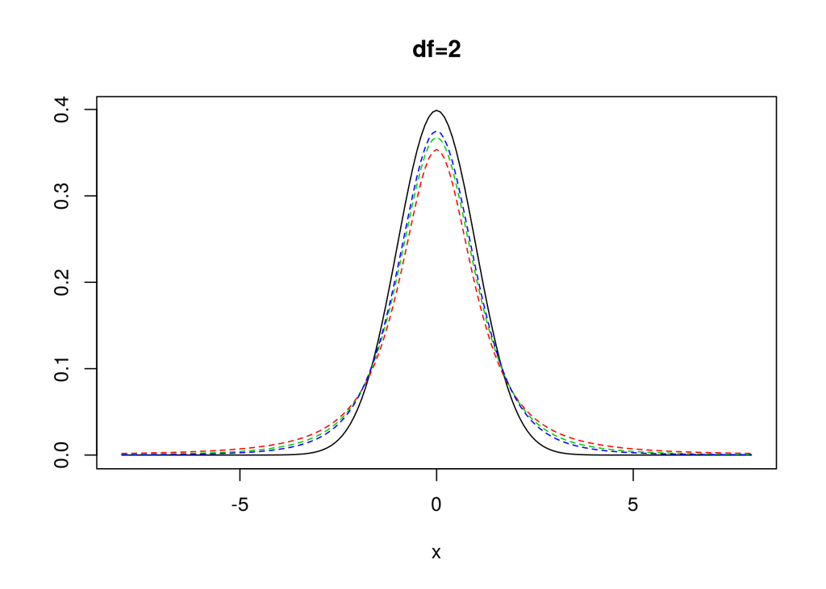

```r
x <- seq(-8,8,by=.1)
{plot(x,dnorm(x),type='l',ylab="",main="df=2")
lines(x,dt(x,df=2),lty=2,col=2)
lines(x,dt(x,df=3),lty=2, col=3)
lines(x,dt(x,df=4),lty=2, col=4)}
```